# Hay.Report for Dec 22, 2018

## This Week

- Introduce Hay.Report
- Benchmark Review

## Thank You

- Jack Carson, Oklahoma Dept of AG-USDA Market News, Oklahoma City, OK
- Heath Dewey, USDA-CO Dept of Ag Market News Service, Greeley, CO
- Lana Hutto, USDA Market News Service, Amarillo, TX
- John Kimbrell, USDA Market News Service, Billings, MT
- Ross Kotewa, USDA-SD Dept of Ag Market News Service, Sioux Falls, SD
- Kim Nettleton, Kansas Department of Agriculture, Manhattan, KS
- Thomas Walthers, USDA NE and USDA WY

## What is Hay.Report?

- Track and analyze prices in hay and forage market
- Montana, Wyoming, South Dakota, Colorado, Nebraska, Kansas, Oklahoma, and Texas
- Feedback encouraged!

## Benchmarks

- Key hay and forage types
- Multi-state & single state

## Alfalfa Benchmarks

| Commodity | Current Price | 1 Wk Change |
| --- | --- | --- |
| Kansas Supreme Dairy | 192 | 0% |
| Multi-State Dehydrated Pellets 17% | 250 | 6% |
| Multi-State Premium Large Squares | 200 | 5% |
| Texas Premium/Supreme | 285 | 0% |

## Multi-State Alfalfa Squares

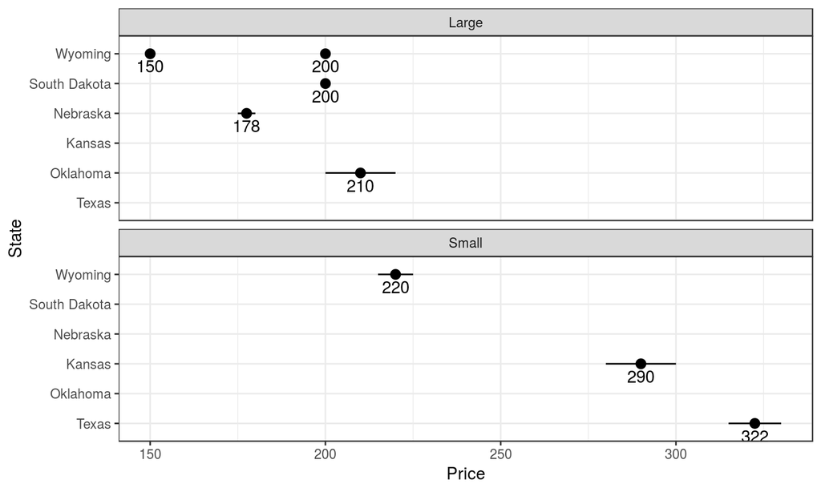

## Third Cutting in NW Wyoming

Thomas Walthers, Wyoming Hay Report, Dec 13, 2018

> Some hay producers are finishing up on their third cutting of alfalfa in the NW area of the state. Other areas of the state it’s been cold and wintery.

## Grass Benchmarks

| Commodity | Current Price | 1 Wk Change |
| --- | --- | --- |
| Kansas Bluestem Large Squares | 120 | -4% |
| Multi-State Good Large Rounds | 98 | -7% |
| Texas G/P Coastal Bermuda Large Rounds | 170 | 0% |

## Shortages in Texas

Lana Hutto, Texas Hay Report, Dec 21, 2018

> Demand was good on limited to moderate supply. A variety of hay continued to be contracted and bought out to meet demands of dairies, feed yards and livestock owners. Coastal Bermuda has become difficult to find as well as the freight to get it to the Panhandle tacks on costs. Producers in East, North and South Texas report there may be a shortage due to army worms, early frosts and rain hampering their 4th cutting.

## Until Next Week

Thank you for watching this test episode of Hay.Report